# クラスタ分析

基本的な考え方と階層的方法

村田 昇

# 講義の内容

- **第1回 : 基本的な考え方と階層的方法**
- 第2回 : 非階層的方法と分析の評価

# クラスタ分析の考え方

## クラスタ分析

- クラスタ分析 (**cluster analysis**) の目的  
  個体の間に隠れている **集まり=クラスタ** を個体間の”距離”にもとづいて発見する方法
- 個体間の類似度・距離(非類似度)を定義
  - 同じクラスタに属する個体どうしは似通った性質
  - 異なるクラスタに属する個体どうしは異なる性質
- さらなるデータ解析やデータの可視化に利用
- 教師なし学習の代表的な手法の一つ

## クラスタ分析の例

- 総務省統計局より取得した都道府県別の社会生活統計指標の一部
  - 総務省 https://www.e-stat.go.jp/SG1/estat/List.do?bid=000001083999&cycode=0

    ```
    都道府県名
    地方区分
    森林面積割合 : 森林面積割合 (%) 2014年
    農業産出額　 : 就業者１人当たり農業産出額(販売農家）(万円) 2014年
    人口割合　　 : 全国総人口に占める人口割合 (%) 2015年
    土地生産性　 : 土地生産性（耕地面積１ヘクタール当たり）(万円) 2014年
    商品販売額　 : 商業年間商品販売額［卸売業＋小売業］（事業所当たり）(百万円) 2013年
    ```

### 都道府県別の社会生活統計指標データ

| 都道府県名 | 地方区分 | 森林面積割合 | 農業算出額 | 人口割合 | 土地生産性 | 商品販売額 |
| --- | --- | --- | --- | --- | --- | --- |
| 北海道 | 北海道 | 67.9 | 1150.6 | 4.23 | 96.8 | 283.3 |
| 青森県 | 東北 | 63.8 | 444.7 | 1.03 | 186.0 | 183.0 |
| 岩手県 | 東北 | 74.9 | 334.3 | 1.01 | 155.2 | 179.4 |
| 宮城県 | 東北 | 55.9 | 299.9 | 1.84 | 125.3 | 365.9 |
| 秋田県 | 東北 | 70.5 | 268.7 | 0.81 | 98.5 | 153.3 |
| 山形県 | 東北 | 68.7 | 396.3 | 0.88 | 174.1 | 157.5 |
| 福島県 | 東北 | 67.9 | 236.4 | 1.51 | 127.1 | 184.5 |
| 茨城県 | 関東 | 31.0 | 479.0 | 2.30 | 249.1 | 204.9 |
| 栃木県 | 関東 | 53.2 | 402.6 | 1.55 | 199.6 | 204.3 |
| 群馬県 | 関東 | 63.8 | 530.6 | 1.55 | 321.6 | 270.0 |
| 埼玉県 | 関東 | 31.9 | 324.7 | 5.72 | 247.0 | 244.7 |
| 千葉県 | 関東 | 30.4 | 565.5 | 4.90 | 326.1 | 219.7 |
| 東京都 | 関東 | 34.8 | 268.5 | 10.63 | 404.7 | 1062.6 |
| 神奈川県 | 関東 | 38.8 | 322.8 | 7.18 | 396.4 | 246.1 |
| 新潟県 | 中部 | 63.5 | 308.6 | 1.81 | 141.9 | 205.5 |
| 富山県 | 中部 | 56.6 | 276.1 | 0.84 | 98.5 | 192.4 |
| 石川県 | 中部 | 66.0 | 271.3 | 0.91 | 112.0 | 222.9 |
| 福井県 | 中部 | 73.9 | 216.1 | 0.62 | 98.5 | 167.3 |
| 山梨県 | 中部 | 77.8 | 287.4 | 0.66 | 325.3 | 156.2 |
| 長野県 | 中部 | 75.5 | 280.0 | 1.65 | 211.3 | 194.4 |
| 岐阜県 | 中部 | 79.0 | 283.7 | 1.60 | 192.1 | 167.9 |
| 静岡県 | 中部 | 63.1 | 375.8 | 2.91 | 314.5 | 211.4 |
| 愛知県 | 中部 | 42.2 | 472.3 | 5.89 | 388.9 | 446.9 |
| 三重県 | 関西 | 64.3 | 310.6 | 1.43 | 174.3 | 170.1 |
| 滋賀県 | 関西 | 50.5 | 222.8 | 1.11 | 104.9 | 170.7 |
| 京都府 | 関西 | 74.2 | 267.8 | 2.05 | 212.5 | 196.7 |
| 大阪府 | 関西 | 30.1 | 216.3 | 6.96 | 238.8 | 451.2 |
| 兵庫県 | 関西 | 66.7 | 261.2 | 4.35 | 197.7 | 212.5 |
| 奈良県 | 関西 | 76.8 | 207.0 | 1.07 | 182.7 | 147.0 |
| 和歌山県 | 関西 | 76.4 | 251.1 | 0.76 | 278.4 | 136.4 |
| 鳥取県 | 中国 | 73.3 | 249.9 | 0.45 | 187.6 | 162.2 |
| 島根県 | 中国 | 77.5 | 214.1 | 0.55 | 140.8 | 141.1 |
| 岡山県 | 中国 | 68.0 | 254.8 | 1.51 | 184.9 | 207.8 |
| 広島県 | 中国 | 71.8 | 286.2 | 2.24 | 192.2 | 304.6 |
| 山口県 | 中国 | 71.6 | 216.9 | 1.11 | 125.8 | 158.9 |
| 徳島県 | 四国 | 75.2 | 315.4 | 0.59 | 313.5 | 134.5 |
| 香川県 | 四国 | 46.4 | 249.5 | 0.77 | 242.9 | 232.9 |
| 愛媛県 | 四国 | 70.3 | 288.5 | 1.09 | 231.6 | 179.4 |
| 高知県 | 四国 | 83.3 | 354.2 | 0.57 | 339.9 | 137.9 |
| 福岡県 | 九州 | 44.5 | 381.0 | 4.01 | 255.6 | 295.7 |
| 佐賀県 | 九州 | 45.2 | 468.7 | 0.66 | 230.3 | 137.9 |
| 長崎県 | 九州 | 58.4 | 428.9 | 1.08 | 296.0 | 154.0 |
| 熊本県 | 九州 | 60.4 | 456.6 | 1.41 | 285.5 | 172.5 |
| 大分県 | 九州 | 70.7 | 360.1 | 0.92 | 222.8 | 148.3 |
| 宮崎県 | 九州 | 75.8 | 739.1 | 0.87 | 487.7 | 170.6 |
| 鹿児島県 | 九州 | 63.4 | 736.5 | 1.30 | 351.2 | 169.4 |
| 沖縄県 | 九州 | 46.1 | 452.4 | 1.13 | 232.8 | 145.4 |

### 散布図

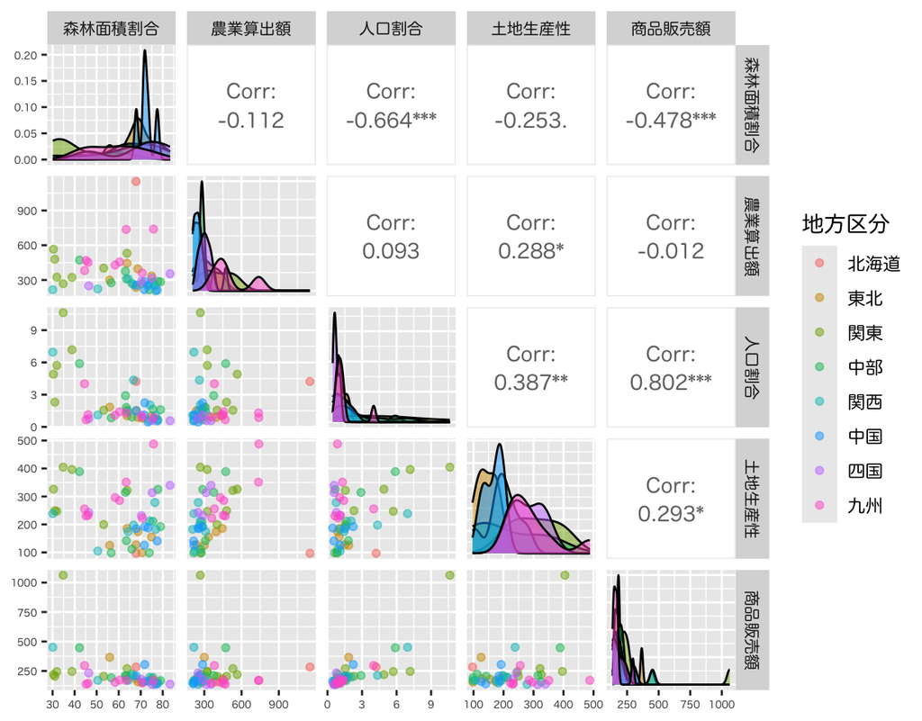

### 主成分得点による散布図

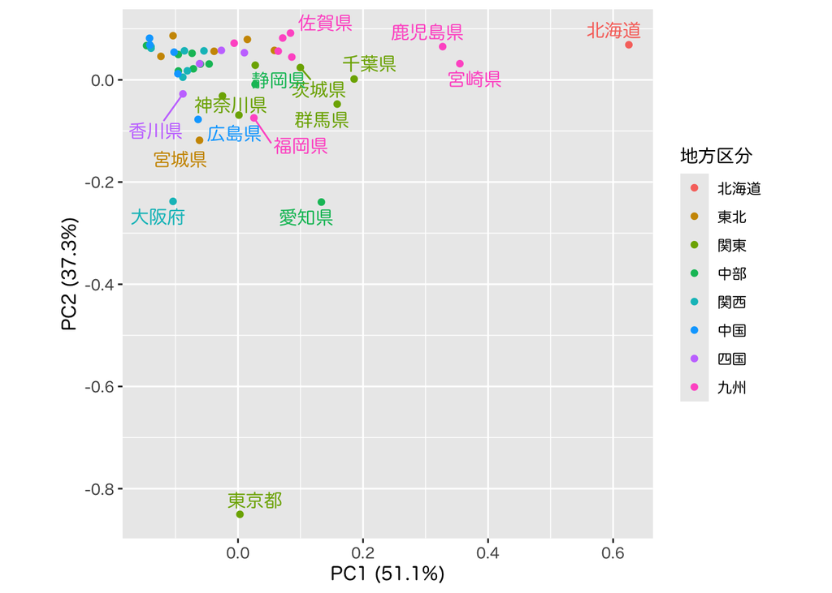

### 散布図上のクラスタ構造 (クラスタ分析の概念図)

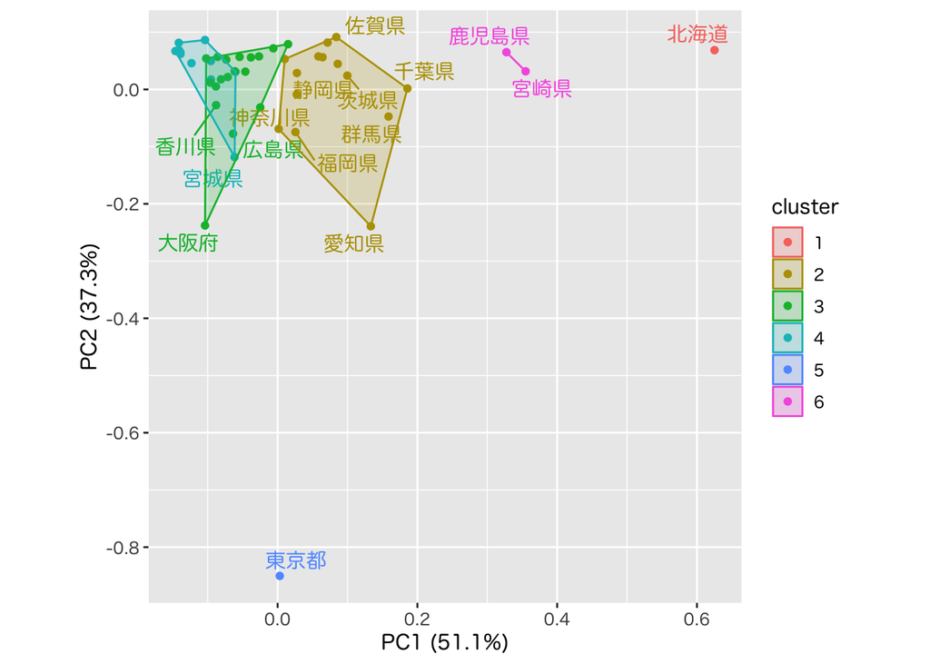

## クラスタ分析の考え方

- 階層的方法
  - データ点およびクラスタの間に **距離** を定義
  - 距離に基づいてグループ化
    - 近いものから順にクラスタを **凝集**
    - 近いものが同じクラスタに残るように **分割**
- 非階層的方法
  - クラスタの数を事前に指定
  - クラスタの **集まりの良さ** を評価する損失関数を定義
  - 損失関数を最小化するようにクラスタを形成

# 階層的方法

## 凝集的クラスタリング

1. データ・クラスタ間の距離を定義する
   - データ点とデータ点の距離
   - クラスタとクラスタの距離
2. データ点およびクラスタ間の距離を求める
3. 最も近い2つを統合し新たなクラスタを形成する
   - データ点とデータ点
   - データ点とクラスタ
   - クラスタとクラスタ
4. クラスタ数が1つになるまで2-3の手続きを繰り返す

### 社会生活統計指標の一部(関東地方)

| 都道府県名 | 森林面積割合 | 農業算出額 | 人口割合 | 土地生産性 | 商品販売額 |
| --- | --- | --- | --- | --- | --- |
| 茨城県 | 31.0 | 479.0 | 2.30 | 249.1 | 204.9 |
| 栃木県 | 53.2 | 402.6 | 1.55 | 199.6 | 204.3 |
| 群馬県 | 63.8 | 530.6 | 1.55 | 321.6 | 270.0 |
| 埼玉県 | 31.9 | 324.7 | 5.72 | 247.0 | 244.7 |
| 千葉県 | 30.4 | 565.5 | 4.90 | 326.1 | 219.7 |
| 東京都 | 34.8 | 268.5 | 10.63 | 404.7 | 1062.6 |
| 神奈川県 | 38.8 | 322.8 | 7.18 | 396.4 | 246.1 |

### データ点の配置

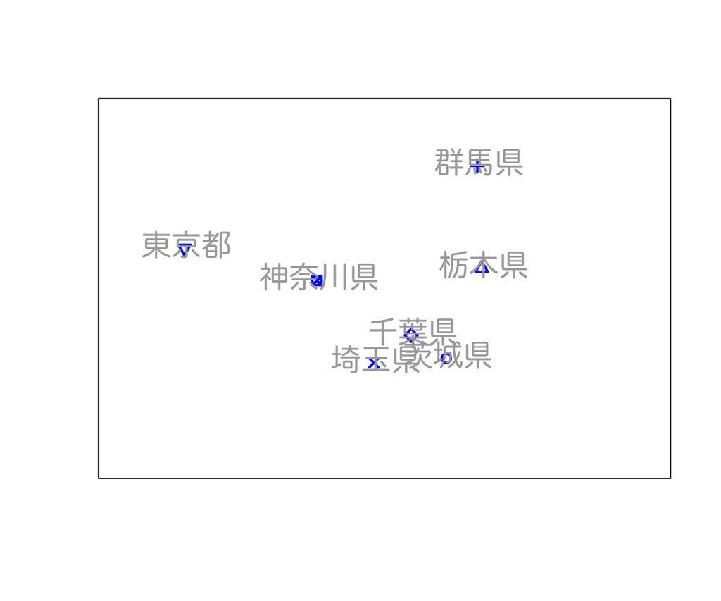

### クラスタリングの手続き (その1)

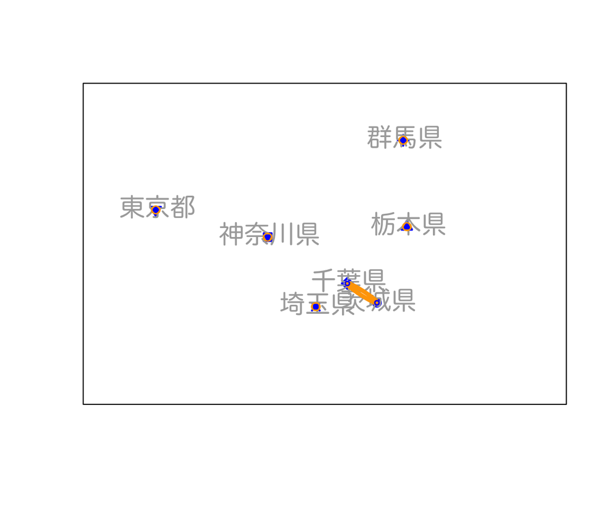

### クラスタリングの手続き (その2)

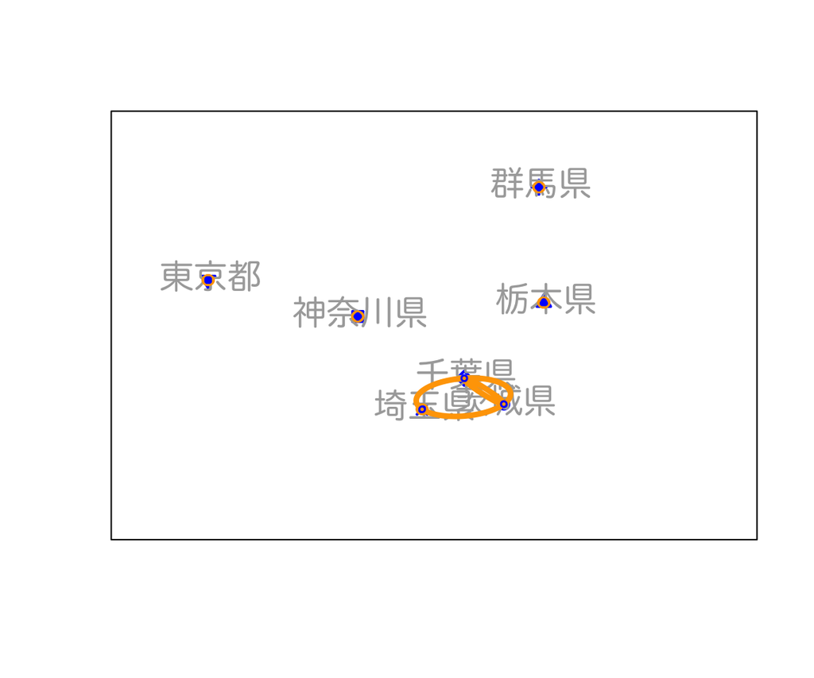

### クラスタリングの手続き (その3)

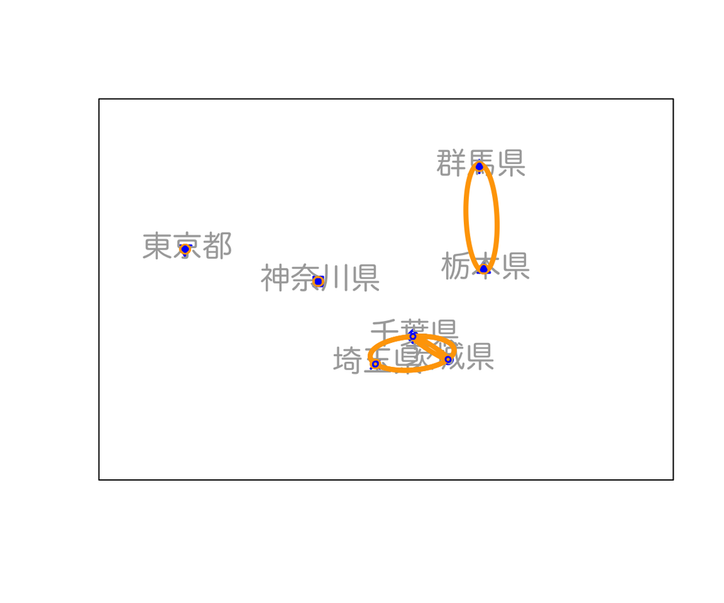

### クラスタリングの手続き (その4)

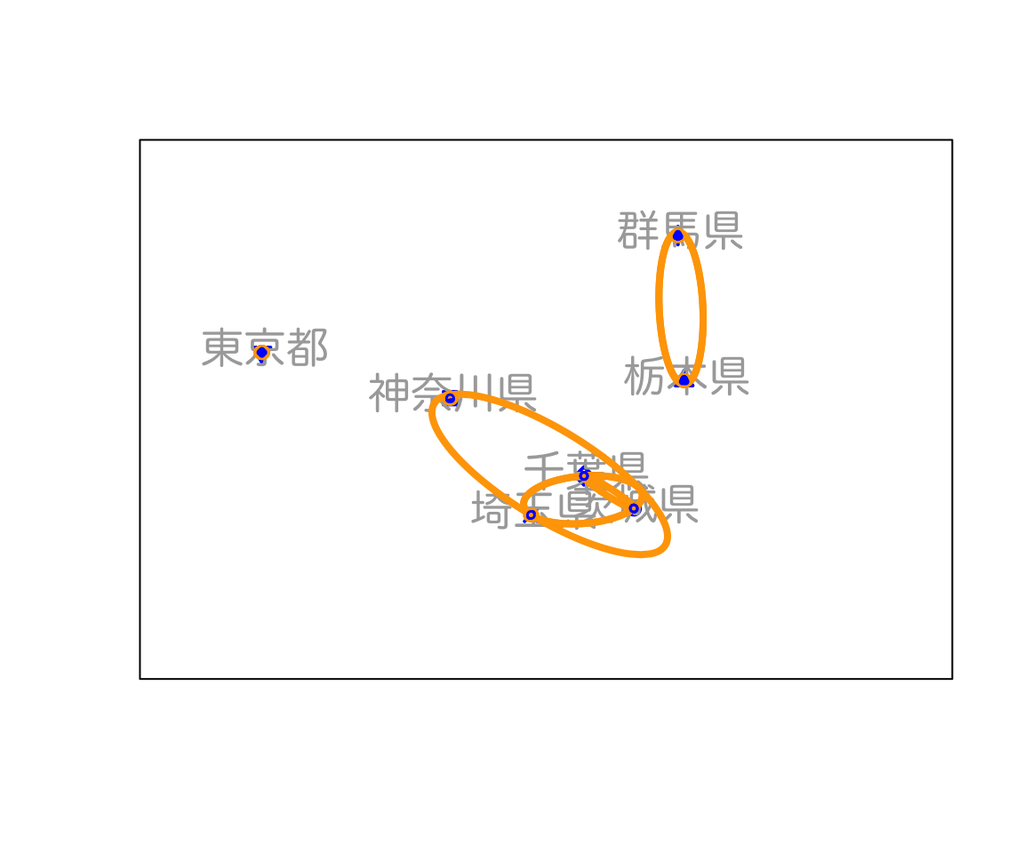

### クラスタリングの手続き (その5)

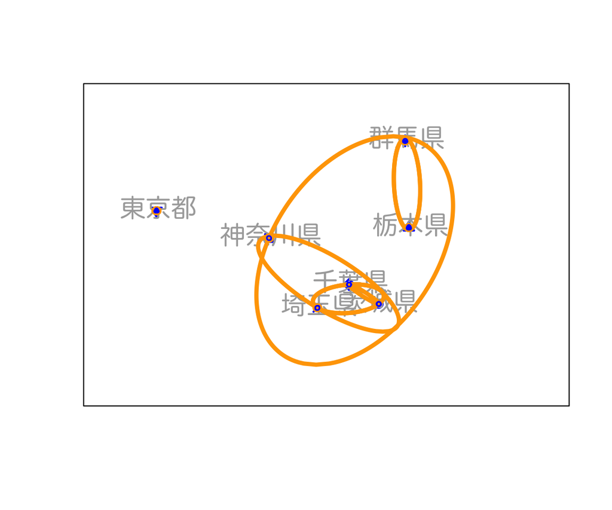

### クラスタリングの手続き (その6)

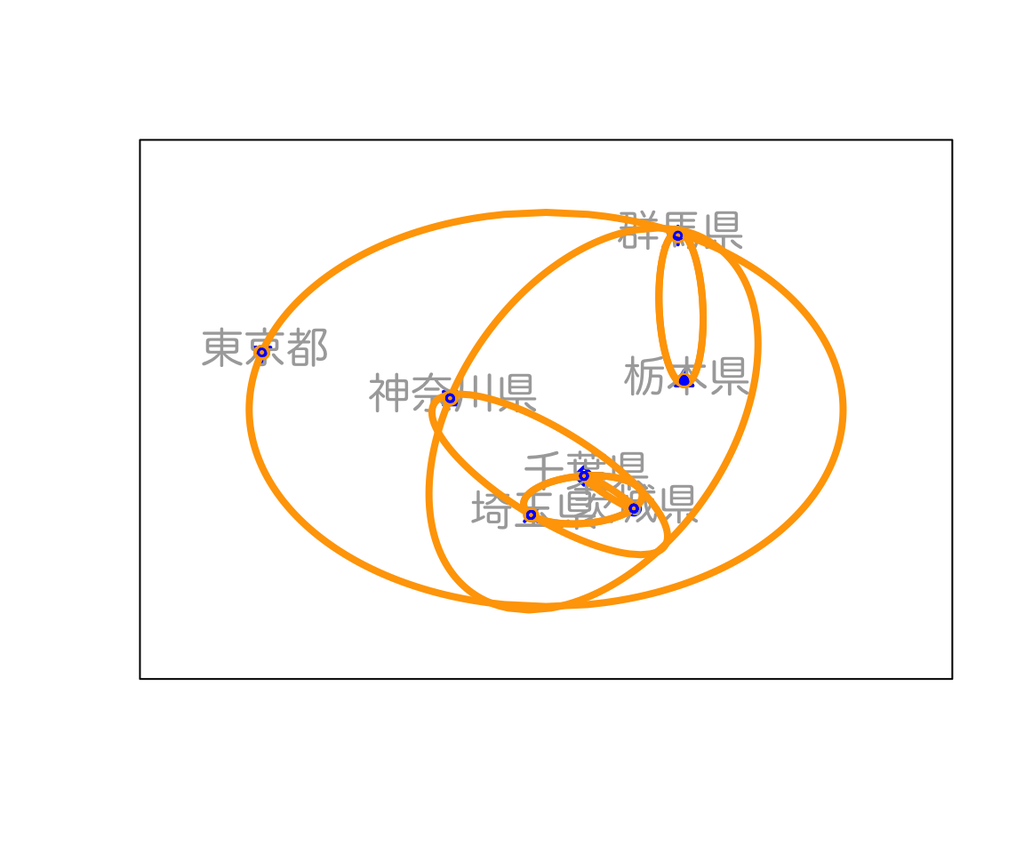

### デンドログラムによるクラスタ構造の表示

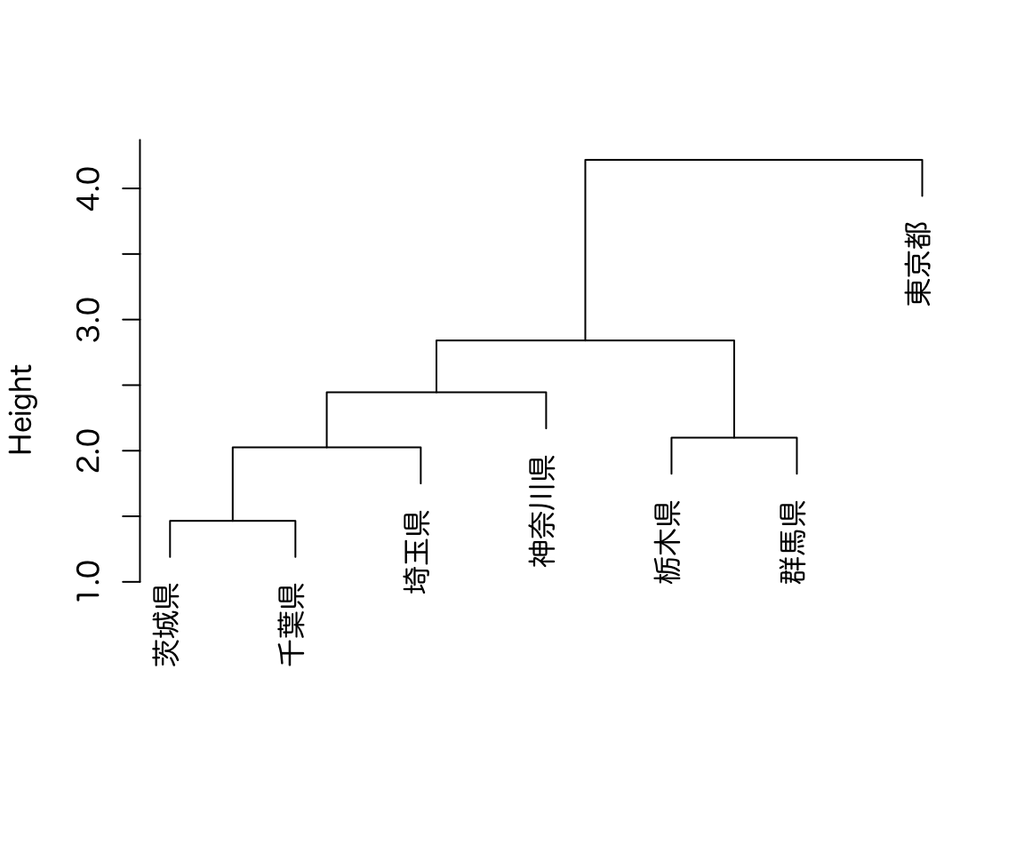

# データ間の距離

## データ間の距離

- データ : 変数の値を成分としてもつベクトル
  $$\begin{equation}
  \boldsymbol{x}=(x_{1},\dotsc,x_{d})^{\mathsf{T}},
  \boldsymbol{y}=(y_{1},\dotsc,y_{d})^{\mathsf{T}}\in\mathbb{R}^{d}
  \end{equation}$$
- 距離 : $d(\boldsymbol{x},\boldsymbol{y})$
- 代表的なデータ間の距離
  - Euclid 距離 (ユークリッド ; Euclidean distance)
  - Manhattan 距離 (マンハッタン ; Manhattan distance)
  - Minkowski 距離 (ミンコフスキー ; Minkowski distance)

## Euclid 距離

- 最も一般的な距離
- 各成分の差の2乗和の平方根 (2ノルム)
  $$\begin{equation}
  d(\boldsymbol{x},\boldsymbol{y})
  =\sqrt{(x_{1}-y_{1})^{2}+\dotsb+(x_{d}-y_{d})^{2}}
  \end{equation}$$

## Manhattan 距離

- 後述する Minkowski 距離の $p=1$ の場合
- 格子状に引かれた路に沿って移動するときの距離
  $$\begin{equation}
  d(\boldsymbol{x},\boldsymbol{y})
  =|x_{1}-y_{1}|+\dotsb+|x_{d}-y_{d}|
  \end{equation}$$

## Minkowski 距離

- Euclid 距離を $p$ 乗に一般化した距離
- 各成分の差の $p$ 乗和の $p$ 乗根($p$-ノルム)
  $$\begin{equation}
  d(\boldsymbol{x},\boldsymbol{y})
  =\bigl\{|x_{1}-y_{1}|^{p}+\dotsb+|x_{d}-y_{d}|^{p}\bigr\}^{1/p}
  \end{equation}$$

## その他の距離

- 類似度や乖離度などデータ間に自然に定義されるものを用いることは可能
  - 語句の共起 (同一文書に現れる頻度・確率)
  - 会社間の取引量 (売上高などで正規化が必要)
- 擬似的な距離でもアルゴリズムは動く

# 実習

# クラスタ間の距離

## クラスタ間の距離

- クラスタ : いくつかのデータ点からなる集合
  $$\begin{equation}
  C_{a}=\left\{\boldsymbol{x}_{i}|i\in\Lambda_{a}\right\},\;
  C_{b}=\left\{\boldsymbol{x}_{j}|j\in\Lambda_{b}\right\},\quad
  C_{a}\cap C_{b}=\emptyset
  \end{equation}$$
- 2つのクラスタ間の距離 : $D(C_{a},C_{b})$
  - データ点の距離から陽に定義する方法
  - クラスタの統合にもとづき再帰的に定義する方法
- 代表的なクラスタ間の距離
  - 最短距離法 (単連結法 ; single linkage method)
  - 最長距離法 (完全連結法 ; complete linkage method)
  - 群平均法 (average linkage method)

## 最短距離法

- 最も近い対象間の距離を用いる方法
  $$\begin{equation}
  D(C_{a},C_{b})
  =\min_{\boldsymbol{x}\in C_{a},\;\boldsymbol{y}\in C_{b}} d(\boldsymbol{x},\boldsymbol{y})
  \end{equation}$$
- 統合前後のクラスタ間の関係
  $$\begin{equation}
  D(C_{a}+ C_{b}, C_{c})
  =\min\bigl\{D(C_{a},C_{c}), D(C_{b},C_{c})\bigr\}
  % =\min\left\{D(C_{a},C_{c}), D(C_{b},C_{c})\right\}
  \end{equation}$$
  - $A+B$は集合$A,B$の直和を表す．

## 最長距離法

- 最も遠い対象間の距離を用いる方法
  $$\begin{equation}
  D(C_{a},C_{b})
  =\max_{\boldsymbol{x}\in C_{a},\;\boldsymbol{y}\in C_{b}} d(\boldsymbol{x},\boldsymbol{y})
  \end{equation}$$
- 統合前後のクラスタ間の関係
  $$\begin{equation}
  D(C_{a}+ C_{b}, C_{c})
  =\max\bigl\{D(C_{a},C_{c}), D(C_{b},C_{c})\bigr\}
  % =\max\left\{D(C_{a},C_{c}), D(C_{b},C_{c})\right\}
  \end{equation}$$

## 群平均法

- 全ての対象間の平均距離を用いる方法
  $$\begin{equation}
  D(C_{a},C_{b})
  =\frac{1}{|C_{a}||C_{b}|}
  \sum_{\boldsymbol{x}\in C_{a},\;\boldsymbol{y}\in C_{b}} d(\boldsymbol{x},\boldsymbol{y})
  \end{equation}$$
  - ただし $|C_{a}|$, $|C_{b}|$ はクラスタ内の要素の数を表す
- 統合前後のクラスタ間の関係
  $$\begin{equation}
  D(C_{a}+ C_{b}, C_{c})
  =\frac{|C_{a}|D(C_{a},C_{c})+|C_{b}|D(C_{b},C_{c})}{|C_{a}|+|C_{b}|}
  \end{equation}$$

## 距離計算に関する注意

- データの性質に応じて距離は適宜使い分ける
  - データ間の距離の選択
  - クラスタ間の距離の選択
- 変数の標準化は必要に応じて行う
  - 物理的な意味合いを積極的に利用する場合はそのまま
  - 単位の取り方などによる分析の不確定性を避ける場合は平均0，分散1に標準化
- データの性質を鑑みて適切に前処理

# 実習

# 次回の予定

- 第1回 : 基本的な考え方と階層的方法
- **第2回 : 非階層的方法と分析の評価**